# PAS Ultimate

# Hodina 1

```r
attach(Kojeni2)
```

#### **Nominální proměnná (slova bez pořadí)**

- absolutní četnost (kolikrát se hodnota vyskytuje)
- relativní četnost (kolik % je hodnota v datasetu)

```r
# vypoctete absolutni a relativni cetnosti pro misto porodu
table(Porodnice) #absolutní (přímo počet kolikrát to tam je)
```

```
Porodnice
 Praha venkov
    70     29
```

```r
prop.table(table(Porodnice))*100 #relativní (kolik % čeho je v datasetu)
```

```
Porodnice
   Praha   venkov
70.70707 29.29293
```

- Kombinovaná proměnná (pořád nominální, jen se vytvoří 4 druhy kombinací místa porodu a pohlaví)

```r
Kombi<-ifelse(hoch==1&Porodnice=="Praha","Hoch z Prahy","Hoch z venkova")
Kombi<-ifelse(hoch==0&Porodnice=="Praha","Divka z Prahy",Kombi)
Kombi<-ifelse(hoch==0&Porodnice=="venkov","Divka z venkova",Kombi)
```

**Vizualizace Nominálních proměnných**

- BAR PLOT / PIE CHART
- Vždy pojmenovat co se dá, osy, graf, legenda, jinak body dolů
- safe to say - využívat barplot je snazší

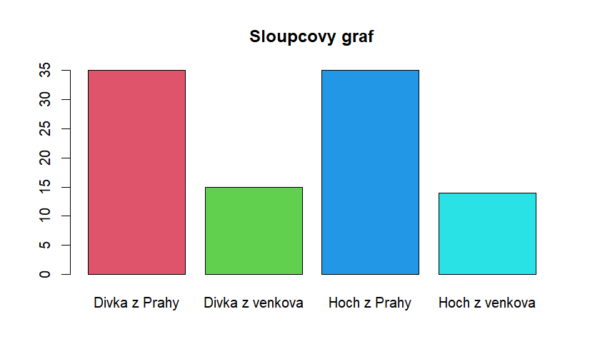

```r
#BARPLOT
barplot(table(Kombi),col=2:5,main="Sloupcovy graf")
```

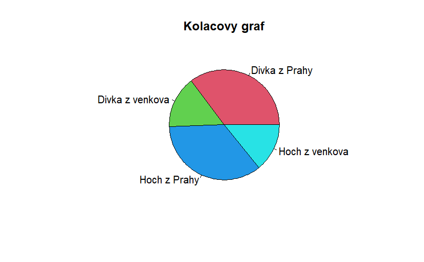

```r
#PIECHART
pie(table(Kombi),col=2:5,main="Kolacovy graf")
```

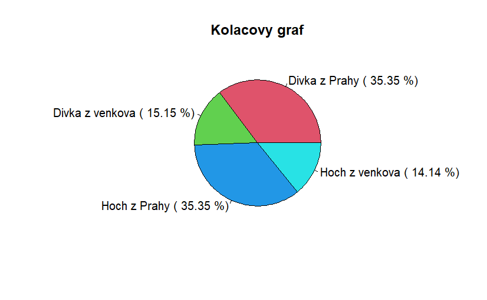

```r
# popisky jednotlivych bodu
leg<-sort(unique(Kombi))
rc<-round(prop.table(table(Kombi))*100,2)
for(i in 1:length(leg)){
  leg[i]<-paste(leg[i],"(",rc[i],"%)")
}
pie(table(Kombi),col=2:5,main="Kolacovy graf",labels=leg)
```

#### **Ordinální proměnná (slova s pořadím)**

```r
table(Vzdelani)
```

```
Vzdelani
maturita       VŠ základní
      47       18       34
```

```r
  # neni usporadano - usporadat
Vzdel<-ordered(Vzdelani,levels=c("základní","maturita","VŠ"))
  # absolutni cetnosti
(ac<-table(Vzdel))
```

```
Vzdel
základní maturita       VŠ
      34       47       18
```

```r
  #  kumulativni absolutni cetnosti (Kumulativní = přičítá se počet od poslední hodnoty (2muži, 5 žen -> 2,7))
(kac<-cumsum(ac))
```

```
základní maturita       VŠ
      34       81       99
```

```r
  # relativni cetnosti
(rc<-round(prop.table(table(Vzdel)),2))
```

```
Vzdel
základní maturita       VŠ
    0.34     0.47     0.18
```

```r
  # kumulativni relativni cetnosti
(krc<-cumsum(rc))
```

```
základní maturita       VŠ
    0.34     0.81     0.99
```

```r
  # v jedne tabulce
cbind("n(i)"=ac,"N(i)"=kac,"p(i)"=rc,"P(i)"=krc)
```

```
         n(i) N(i) p(i) P(i)
základní   34   34 0.34 0.34
maturita   47   81 0.47 0.81
VŠ         18   99 0.18 0.99
```

**Vizualizace**

- Bar plot(pie-chart-fuj taky jde), histogram, frekvenční polygon

#### **Číselná diskrétní proměnná (int)**

- počet něřeho např.
- Vizualizace - **frekvenční polygon**, histogram(pokud má hodně hodnot), boxplot, bar plot spíš ne
- počítám Frekvenčí rozdělení

```r
  # popis histogramu, ktery se nenakresli
hist(trvani,plot=F)
```

```
$breaks
[1]  0  5 10 15 20 25

$counts
[1] 18 15 14 24 28

$density
[1] 0.03636364 0.03030303 0.02828283 0.04848485 0.05656566

$mids
[1]  2.5  7.5 12.5 17.5 22.5

$xname
[1] "trvani"

$equidist
[1] TRUE

attr(,"class")
[1] "histogram"
```

```r
  # delici body
deleni<-hist(trvani,plot=F)$breaks
  # popis intervalu
popis<-as.character(deleni[-1])
for(i in 1:length(popis)){
  popis[i]<-paste("(",deleni[i],",",deleni[i+1],"]")
}

  # absolutni cetnosti v intervalech
ac<-hist(trvani,plot=F)$counts
  # kumulativni absolutni cetnosti
kac<-cumsum(ac)
  # relativni cetnosti
rc<-round(ac/sum(ac),3)
  # kumulativni relativni cetnosti
krc<-cumsum(rc)
  # v jedne tabulce
cbind(" "=popis,"n(i)"=ac,"N(i)"=kac,"f(i)"=rc,"F(i)"=krc)
```

```
                   n(i) N(i) f(i)    F(i)
[1,] "( 0 , 5 ]"   "18" "18" "0.182" "0.182"
[2,] "( 5 , 10 ]"  "15" "33" "0.152" "0.334"
[3,] "( 10 , 15 ]" "14" "47" "0.141" "0.475"
[4,] "( 15 , 20 ]" "24" "71" "0.242" "0.717"
[5,] "( 20 , 25 ]" "28" "99" "0.283" "1"
```

Vizualizace

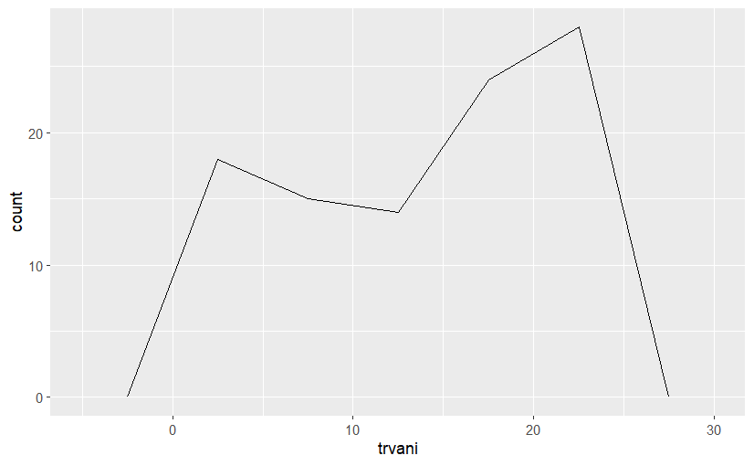

```r
library(ggplot2)

#Frekvenční polygon
ggplot(Kojeni2, aes(trvani)) +  geom_freqpoly(breaks = deleni)
```

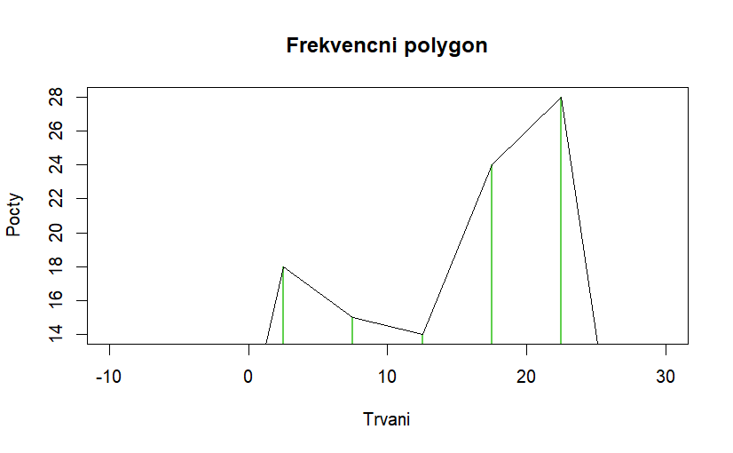

```r
#Frekvenční polygon 2.způsob
x<-hist(trvani,plot=F)$mids
ac<-hist(trvani,plot=F)$counts
plot(x,ac,col=3,lwd=2,type="h",xlim=c(-10,30),main="Frekvencni polygon",xlab="Trvani",ylab="Pocty")
lines(c(-2.5,x,27.5),c(0,ac,0))
```

#### **Číselná spojitá proměnná (float)**

- Vizualizace - frekvenční polygon, **histogram, boxplot**

```r
#prumer
mean(por.hmotnost)
```

```
[1] 3469.576
```

```r
# vybrane percentily: minumim, dolni kvartil, median, horni kvartil a maximum
quantile(por.hmotnost,c(0,1/4,1/2,3/4,1))
```

```
  0%  25%  50%  75% 100%
2040 3200 3480 3720 4400
```

```r
fivenum(por.hmotnost) #lepší způsob
```

```
[1] 2040 3200 3480 3720 4400
```

```r
# zakladni popisne statistiky polohy
summary(por.hmotnost) #Dělá to samé, ale popíše a ukáže i median i průměr
```

```
   Min. 1st Qu.  Median    Mean 3rd Qu.    Max.
   2040    3200    3480    3470    3720    4400
```

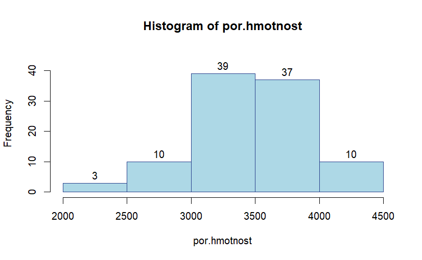

```r
#Vizualizace - histogram
hist(por.hmotnost,labels=T,col="lightblue",border="royalblue4",ylim=c(0,45))
```

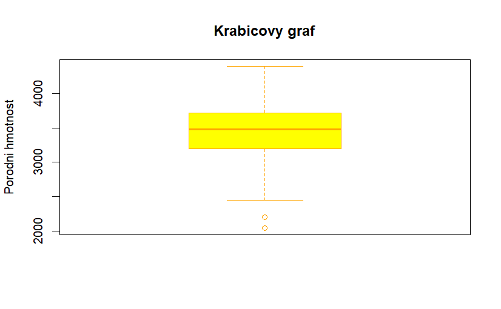

```r
#Vizualizace - boxplot
boxplot(por.hmotnost,main="Krabicovy graf",ylab="Porodni hmotnost",col="yellow",border="orange")
```

# Hodina 2

```r
attach(prij)
library(DescTools)
```

#### Popisné statistiky variability

- **Směrodatná odchylka (SD) (standardní odchylka)**
  - pro měření rozptylu dat vůči aritmetickému průměru
  - je v původních jednotkách dat
  - Pokud se číslo hodně liší od průměru tak ukazuje velký rozptyl
  - většina dat je rozptýlena “číslo SD” od průměru
- **Výběrový rozptyl (VAR)**
  - SD^2
  - Vysoká hodnota = vyšší rozptyl hodnot
- **Mezikvartilové rozpětí (IQR)**
  - **Definice:** Rozsah hodnot ve středu rozdělení dat
  - **Význam:** Poskytuje informaci o šíři rozložení dat kolem středu souboru.
  - **Výpočet:**
    - **Seřazení dat:** Nejprve se data seřadí od nejnižší hodnoty po nejvyšší.
    - **Určení kvartilů:** Potřebujeme první kvartil (Q1) a třetí kvartil (Q3).
      - První kvartil (Q1) je hodnota, pod kterou je 25 % nejnižších dat.
      - Třetí kvartil (Q3) je hodnota, pod kterou je 75 % nejnižších dat.
    - **Výpočet IQR:** IQR je rozdíl mezi třetím a prvním kvartilem (IQR = Q3 - Q1).

  IQR poskytuje informaci o rozsahu, ve kterém se nachází středních 50 % dat (tedy od 25 % do 75 % nejnižších hodnot).
- **Mediánová absolutní odchylka (MAD)**
  - SD ale místo průměru medián
- **Variační koeficient (CoefVar)**
  - **Definice:** Poměr směrodatné odchylky k aritmetickému průměru, vyjádřený jako procento.
  - **Význam:** Porovnává variabilitu dat relativně k jejich průměru a umožňuje srovnání rozptylu mezi různými soubory.
  - **Výpočet:** Směrodatná odchylka vydělená aritmetickým průměrem, násobeno 100 pro vyjádření v procentech.

```r
znamky<-prij$ss2 # Průměr známek za pololetí
sd(znamky) # Směrodatná odchylka
```

```
[1] 0.4591117
```

```r
var(znamky) # Vyberovy rozptyl
```

```
[1] 0.2107835
```

```r
IQR(znamky) # Mezikvartilové rozpětí
```

```
[1] 0.57
```

```r
MAD(znamky) # Mediánová absolutní odchylka
```

```
[1] 0.437367
```

```r
CoefVar(znamky) # Variační koeficient
```

```
[1] 0.2622896
```

#### Charakteristiky tvaru rozdeleni

- **Šikmost (Skew)**
  - **Definice:** Míra asymetrie rozdělení dat, která ukazuje, jak moc se rozdělení odchyluje od symetrie.
  - **Význam:** Pozitivní hodnota indikuje, že vyšší hodnoty mají tendenci být více rozptýleny vpravo od průměru, zatímco negativní hodnota naznačuje rozptýlení vlevo.
  - **Výpočet:** Míra momentů třetího řádu ve vztahu k směrodatné odchylce.
  - **Vysoká hodnota:**
    - **Kladná hodnota:** Označuje, že distribuce je asymetrická s dlouhou ocasem směrem doprava (vpravo).
    - **Záporná hodnota:** Indikuje asymetrii s dlouhou ocasem směrem doleva (vlevo).
  - Rozmezí pro hodnoty může být většinou od -2 do 2.
- **Špičatost (Kurt)**
  - **Definice:** Míra „ostrého vrcholu” nebo „plochého vrcholu” v rozložení dat, měřící, jak moc jsou data koncentrována kolem středu.
  - **Význam:** Vyšší hodnota znamená větší koncentraci dat kolem průměru s výraznějším vrcholem nebo hustším rozdělením.
  - **Výpočet:** Míra momentů čtvrtého řádu ve vztahu k směrodatné odchylce.
  - **Vysoká hodnota:** Vyšší hodnota kurtózy naznačuje, že data mají vyšší koncentraci kolem průměru s výraznějším a špičatějším vrcholem.
  - **Nízká hodnota:** Nižší kurtóza naznačuje, že rozložení je plošší, s menším množstvím dat koncentrovaných kolem průměru.
  - Hodnota 3 = symetrické rozdělení, větší než 3 je velká špička a velký ocasy a menší než 3 placatější vrchol

```r
Skew(prom4)
```

```
[1] 0.7613504
```

```r
Kurt(prom4)
```

```
[1] 1.489601
```

```r
# kvartilovy koeficient sikmosti = Skew ale rozepsaný ručně
Q1<-quantile(prom1,0.25)
Q3<-quantile(prom1,0.75)
(Q3+Q1-2*median(prom1))/(Q3-Q1)
```

```
75%
  0
```

```r
# oktilovy koeficient spicatosti = Kurt ale rozepsaný ručně
Q18<-quantile(prom1,1/8)
Q28<-quantile(prom1,2/8)
Q38<-quantile(prom1,3/8)
Q48<-quantile(prom1,4/8)
Q58<-quantile(prom1,5/8)
Q68<-quantile(prom1,6/8)
Q78<-quantile(prom1,7/8)
((Q78-Q58)+(Q38-Q18))/(Q68-Q28)
```

```
87.5%
 1.75
```

#### Jak popisné statistiky polohy, variability a tvaru rozdělení reagují na posunutí a změnu měřítka?

```r
prom4.p<-prom4+10
prom4.m<-prom4*10
  # nove promenne
vyst<-matrix(NA,3,4)
vyst[1,1]<-mean(prom4);vyst[1,2]<-sd(prom4);vyst[1,3]<-Skew(prom4);vyst[1,4]<-Kurt(prom4)
vyst[2,1]<-mean(prom4.p);vyst[2,2]<-sd(prom4.p);vyst[2,3]<-Skew(prom4.p);vyst[2,4]<-Kurt(prom4.p)
vyst[3,1]<-mean(prom4.m);vyst[3,2]<-sd(prom4.m);vyst[3,3]<-Skew(prom4.m);vyst[3,4]<-Kurt(prom4.m)
rownames(vyst)<-c("ss2","ss2+10","ss2*10")
colnames(vyst)<-c("Prumer","Sm.odchylka","Sikmost","Spicatost")
vyst
```

```
         Prumer Sm.odchylka   Sikmost Spicatost
ss2     79.9392    10.99702 0.7613504  1.489601
ss2+10  89.9392    10.99702 0.7613504  1.489601
ss2*10 799.3920   109.97017 0.7613504  1.489601
```

#### Z-skóre

- **Definice:** Míra, která vyjadřuje, o kolik směrodatných odchylek se daná hodnota odchyluje od průměru dané proměnné.
- **Význam:** Normalizuje data tak, aby měla průměr 0 a směrodatnou odchylku 1, umožňuje porovnávat a interpretovat data napříč různými proměnnými.
- **Výpočet:** Rozdíl mezi hodnotou a průměrem dané proměnné dělený směrodatnou odchylkou dané proměnné.
- **Vysoká hodnota:**
  - Z-Score větší než 0: Hodnota je nad průměrem a její odchylka je větší než standardní odchylka.
  - Z-Score menší než 0: Hodnota je pod průměrem a její odchylka je větší než standardní odchylka, ale v opačném směru.
- **Nízká hodnota:**
  - Z-Score blízko 0: Hodnota se blíží průměru a má menší odchylku od něj.
- **Příklad**
  - Pokud máme dataset s věkovými hodnotami a průměrem věku 30 let a směrodatnou odchylkou 5 let, pak:
    - Z-Score 0 znamená, že hodnota je přesně na průměru.
    - Z-Score +1 znamená, že hodnota je o 5 let nad průměrem.
    - Z-Score -1 znamená, že hodnota je o 5 let pod průměrem.

```r
z.val<-scale(prom4)
z.val
```

```
               [,1]
  [1,] -0.812875263
  [2,] -0.449140272
  [3,]  1.369534683
  [4,]  1.642335927
  [5,]  1.551402179
  [6,]  0.278329710
  [7,] -0.994742759
  [8,]  0.187395962
  [9,]  1.096733440
 [10,] -0.812875263
 [11,]  0.005528467
 [12,] -1.449411497
 [13,]  2.642607152
 [14,]  1.460468431
```

[output cut: 944 more lines]

# Hodina 3

```r
attach(Policie)
```

### Modus

- Modus je hodnota, která se v datasetu vyskytuje nejčastěji.
- V datasetu může být více hodnot, které se vyskytují stejně často a jsou tedy všechny modusy. (1 modus = unimodální rozdělení
- V histogramu je to ten “nejvyšší obdélník”

# Hodina 4

```r
names(Stulong)<-c("ID","vyska","vaha","syst1","syst2","chlst","vino","cukr","bmi",
                  "vek","KOURrisk","Skupina","VekK")
```

#### Modus pro DISKRÉTNÍ proměnné (s mnoha kategoriemi)

- Modus je konkrétní hodnota, která se opakuje nejčastěji.

```r
# Urcete modus pro cukr
cukr = Stulong$cukr


meze<-hist(cukr,plot=F)$breaks
pocty<-hist(cukr,plot=F)$counts
m<-which.max(pocty)
(A<-meze[m])
```

```
[1] 0
```

```r
(h<-meze[2]-meze[1])
```

```
[1] 2
```

```r
(d0<-pocty[m]-0)  # pocty[m-1] => 0  protože pokud sousedni sloupec k tomu nejvyssimu chybi, bere se jeho cetnost jako 0
```

```
[1] 284
```

```r
(d1<-pocty[m]-pocty[m+1]) # kdyby chyběl sousední sloupec tady tak dám 0 místo pocty[m+1]
```

```
[1] 25
```

```r
(modus_rovnice<-A + h*d0/(d0+d1))
```

```
[1] 1.838188
```

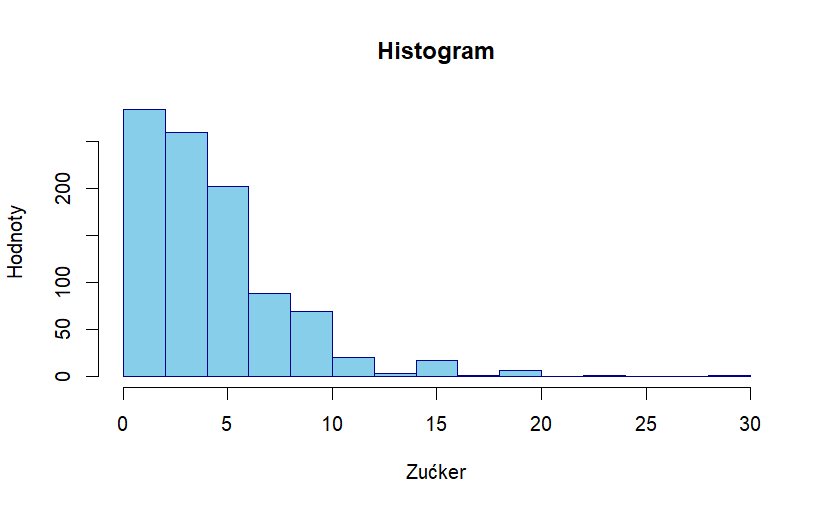

```r
#Rovnice (Histogram) = když je hodně různých hodnot + diskrétní
hist(cukr,col="skyblue",border="darkblue",main="Histogram",ylab="Hodnoty",
     xlab="Zućker")
```

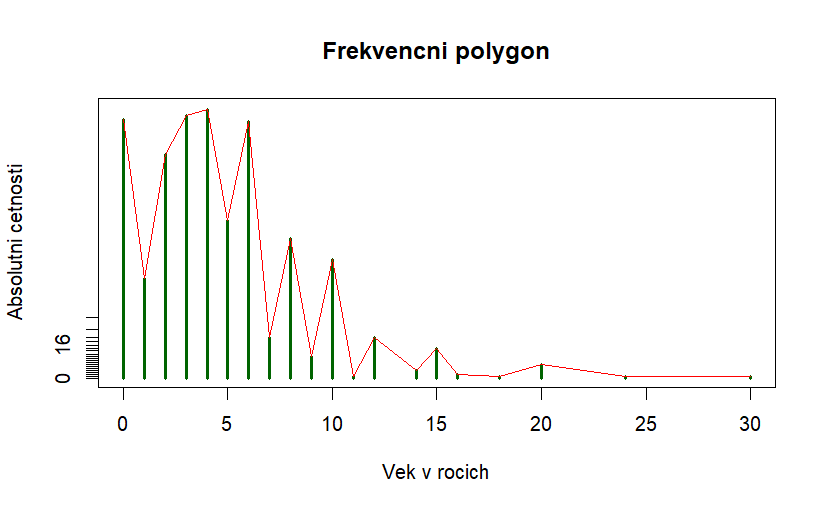

```r
#Přes Frekvenční polygon (Vestavěný) = když je málo podobných hodnot
x.val<-sort(unique(cukr))
ac = table(cukr)
modus_desc = x.val[which.max(ac)]

plot(x.val,ac,type="h",lwd=3,col="darkgreen",main="Frekvencni polygon",
     xlab="Vek v rocich",ylab="Absolutni cetnosti")
lines(x.val,ac,col="red")
```

```r
cat(
  "Přeš DescTools() pokud je málo a podobných hodnot: ", modus_desc, "\n",
  "Přeš Rovnici pokud je hodně různých hodnot: ", modus_rovnice,
  "Přeš Mode(): ", Mode(cukr), "\n"
)
```

```
Přeš DescTools() pokud je málo a podobných hodnot:  4
 Přeš Rovnici pokud je hodně různých hodnot:  1.838188 Přeš Mode():  4
```

#### Modus pro SPOJITÉ proměnné

- Modus může být identifikován spíše jako interval nebo rozsah hodnot, které se vyskytují nejčastěji.

```r
# najdete modus pro spojitou promennou bmi
bmi<-Stulong$bmi
hist(bmi,col="skyblue",border="darkblue",main="Histogram",ylab="Hustota",
     xlab="Vyska v cm",freq=F)
(jadro<-density(bmi, bw=1)) #bandwith(bw) mění hladkost funkce
```

```
Call:
    density.default(x = bmi, bw = 1)

Data: bmi (954 obs.);   Bandwidth 'bw' = 1

       x               y
 Min.   :13.98   Min.   :4.730e-06
 1st Qu.:22.48   1st Qu.:4.097e-04
 Median :30.97   Median :3.201e-03
 Mean   :30.97   Mean   :2.940e-02
 3rd Qu.:39.47   3rd Qu.:4.076e-02
 Max.   :47.96   Max.   :1.442e-01
```

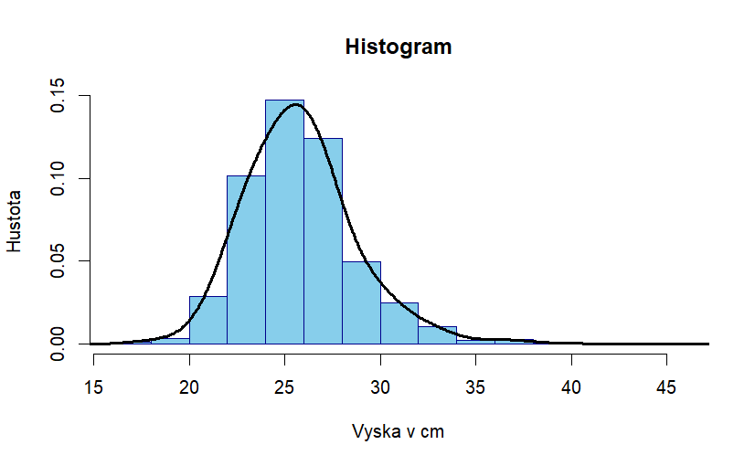

```r
lines(jadro,col=1,lwd=3)
```

```r
#jde spočítat vzorečkem
meze<-hist(bmi,plot=F)$breaks
pocty<-hist(bmi,plot=F)$counts
m<-which.max(pocty)
(A<-meze[m])
```

```
[1] 24
```

```r
(h<-meze[2]-meze[1])
```

```
[1] 2
```

```r
(d0<-pocty[m]-pocty[m-1])
```

```
[1] 87
```

```r
(d1<-pocty[m]-pocty[m+1])
```

```
[1] 44
```

```r
(modus_bmi<- A + h*d0/(d0+d1))
```

```
[1] 25.32824
```

### Odlehlé hodnoty

#### IQR

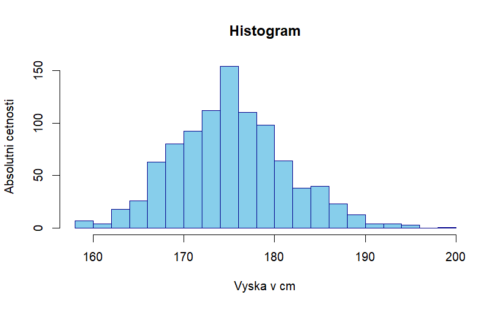

```r
prom3<-Stulong$vyska
# Je promenna symetricka nebo sesikmena? <- symetrická = normální rozdělení = gaussova křivka, sešikmená = má ocas
#   A je jeji rozdeleni jednovrcholove nebo vicevrcholove?
hist(prom3,col="skyblue",border="darkblue",main="Histogram",ylab="Absolutni cetnosti",
     xlab="Vyska v cm",breaks=15)
```

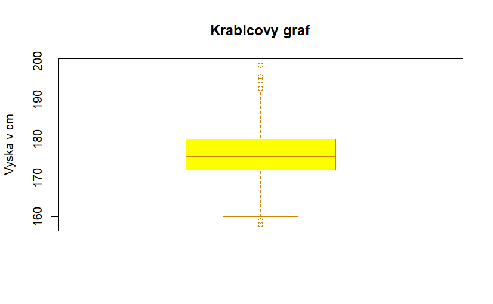

```r
# A co na odlehle hodnoty rika boxplot?
boxplot(prom3,col="yellow",border="orange3",main="Krabicovy graf",
        ylab="Vyska v cm")
```

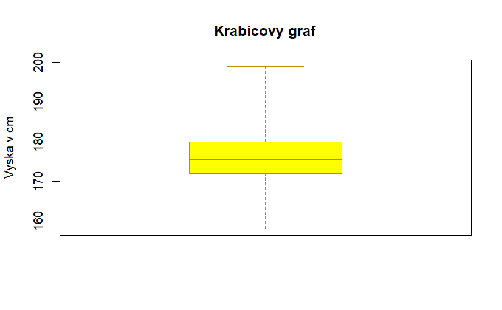

```r
  # Vidime adepty na odlehle hodnoty
# Zprisnime pravidlo
boxplot(prom3,col="yellow",border="orange3",main="Krabicovy graf",
        ylab="Vyska v cm", range=3)
```

```r
# Výpočet kvartilů
quartiles <- quantile(prom3, probs = c(0.25, 0.75))
# Určení mezí pro odlehlé hodnoty
IQR <- IQR(prom3)
# 1.5 nasobek mezikvartiloveho rozpeti (defaultní hodnota v boxplotu bez přepisování range je 1.5, tedy toto)
lower_limit <- quartiles[1] - 1.5 * IQR
upper_limit <- quartiles[2] + 1.5 * IQR
# Identifikace odlehlých hodnot
outliers <- prom3[prom3 < lower_limit | prom3 > upper_limit]
(sort(outliers))
```

```
 [1] 158 159 193 193 193 193 195 196 196 199
```

```r
quartiles <- quantile(prom3, probs = c(0.25, 0.75))
# 3 nasobek mezikvartiloveho rozpeti - odlehla pozorovani (v boxplotu range = 3)
lower_limit <- quartiles[1] - 3 * IQR
upper_limit <- quartiles[2] + 3 * IQR
# Identifikace odlehlých hodnot
outliers <- prom3[prom3 < lower_limit | prom3 > upper_limit]
(sort(outliers)) # v tomhle případě nic nenajde
```

```
numeric(0)
```

```r
#Takhle se dají najít jednoduše, v podstatě automaticky vypočítá ty výpočty IQR, ale nejde měnit range
outliers <- boxplot.stats(prom3)$out
cat("Outliery:", sort(outliers), "\n")
```

```
Outliery: 158 159 193 193 193 193 195 196 196 199
```

#### Z-score

- Udává o kolik směrodatných odchylek je hodnota daleko od aritmetického průměru
- Outliery můžeme brát jako hodnoty co mají z-score 2x nebo 3x větší
- Není robustní

```r
#Z-SKÓRE

mean_value <- mean(prom3)
sd_value <- sd(prom3)
# Výpočet Z-Skóre pro každou hodnotu v datasetu
z_scores <- (prom3 - mean_value) / sd_value
# Nastavení prahu pro identifikaci outlierů (např. Z-Skóre vyšší než 2)
threshold <- 2
# Identifikace outlierů na základě Z-Skóre
outliers <- prom3[abs(z_scores) > threshold]
# Výpis outlierů
print(sort(outliers))
```

```
 [1] 158 159 160 160 160 160 160 161 161 161 162 163 163 163 163 163 163 163 189 189 189 189 189 189 190 190 190 190 190 190 190 191 192 192
[35] 192 193 193 193 193 195 196 196 199
```

```r
#SD není robustní, v podstatě je to horší verze IQR
sd = sd(prom3)

quartiles <- quantile(prom3, probs = c(0.25, 0.75))
lower_limit <- quartiles[1] - 1.5 * sd
upper_limit <- quartiles[2] + 1.5 * sd
# Identifikace odlehlých hodnot
outliers <- prom3[prom3 < lower_limit | prom3 > upper_limit]
(sort(outliers))
```

```
 [1] 158 159 160 160 160 160 160 161 161 161 162 190 190 190 190 190 190 190 191 192 192 192 193 193 193 193 195 196 196 199
```

```r
quartiles <- quantile(prom3, probs = c(0.25, 0.75))
lower_limit <- quartiles[1] - 3 * sd
upper_limit <- quartiles[2] + 3 * sd
# Identifikace odlehlých hodnot
outliers <- prom3[prom3 < lower_limit | prom3 > upper_limit]
(sort(outliers))
```

```
[1] 199
```

- Pokud nejsou data symetrická tak je nejdřív symetrizuji logaritmem (normalizuji, normální, nevím proč ale tenhle předmět má pro jednu věc 6 názvů)

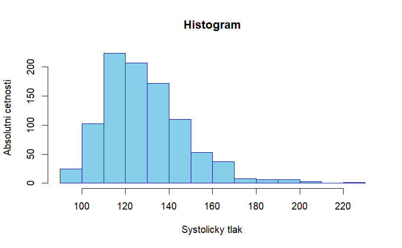

```r
prom4<-Stulong$syst1
hist(prom4,col="skyblue",border="darkblue",main="Histogram",ylab="Absolutni cetnosti",
     xlab="Systolicky tlak")
```

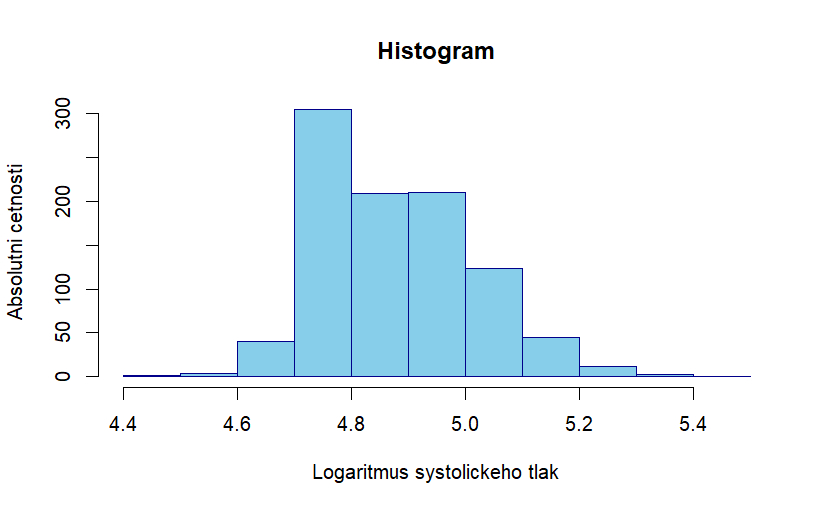

```r
  # zde uz je sesikmeni vyraznejsi, zkusime symetrizujici transformaci
ln.prom4<-log(prom4)  #to ln.prom4 není nic special, akorát černíková neumí programovat takže píše do názvů tečky :)
hist(ln.prom4,col="skyblue",border="darkblue",main="Histogram",ylab="Absolutni cetnosti",
     xlab="Logaritmus systolickeho tlak")
```

```r
  # pomohlo to? Odlehle hodnoty se hledaji u symetrizovane promenne
```